# Análise Exploratória do Projeto High School and Beyond (HS&B)

## 1. Introdução

O presente relatório apresenta uma análise exploratória do dataset **hsb2f.csv**, composto por dados coletados por meio de uma pesquisa de base com alunos do último e segundo ano do ensino médio nos Estados Unidos. A primeira survey nacional foi aplicada em 1980. De acordo com o Centro Nacional para Estudos da Educação NCES( s/d), o modelo amostral inicial previa 1.100 escolas com 36 alunos do último ano e 36 do segundo ano por escola. Os instrumentos de pesquisa incluíram: questionário do segundo ano, questionário do último ano, páginas de identificação do aluno, séries de testes cognitivos para cada coorte, questionário escolar, lista de verificação de comentários do professor e questionário dos pais. A pesquisa foi realizada em sequência de 1983 a 1986 e, após um intervalo, em 1992, 1993 e 2015. De acordo com Tatsuoka (1988), até 1986, foram coletados dados de 58.270 estudantes do ensino médio (28.240 veteranos e 30.030 alunos do segundo ano) em 1.015 escolas secundárias. O High School and Beyond Project (em português Projeto Ensino Médio e Além) foi um **estudo longitudinal** dos estudantes do ensino médio e também após o témino de sua formação realizado pelo National Center for Education Statistics (United States Department of Education, 2006). Um *estudo longitudinal* é um tipo de estudo observacional que coleta dados de forma consistente de um mesmo grupo de pessoas ao longo de um período de tempo prolongado. O objetivo é monitorar mudanças de opinião e experiências, identificar problemas, descobrir estratégias para melhorar uma área específica e medir o impacto dessas estratégias (QESTIONPRO, 2024). O dataframe utilizado neste trabalho, denominado **hsb2f.csv** (OPENINTRO, s/d) é uma amostra contendo 200 observações do estudo original, aleatoriamente selecionadas, de características desconhecidas, dos alunos do último ano do ensino médio, originalmente selecionadas das 600 observações utilizadas em Tatsuoka (1988).

## 2. Carregando as bibiotecas

```python
import pandas as pd
import matplotlib.pyplot as plt
import numpy as np
import seaborn as sns
```

## 3. Importando os dados

```python
data = pd.read_csv("../dados/hsb2f.csv", sep=";")
df = data.loc[:, data.columns != 'id']
```

### 3.1 Visualizando o dataframe

```python
sns.set(style="whitegrid")
```

```python
df.head(10) # visualizando as 10 primeiras linhas do dataframe
```

|  | genero | raca | clasocial | tipescola | programa | ler | escrever | matematica | ciencias | estsociais |
| --- | --- | --- | --- | --- | --- | --- | --- | --- | --- | --- |
| 0 | masculino | branca | baixa | pública | básico | 57 | 52 | 41 | 47 | 57 |
| 1 | feminino | branca | média | pública | técnico | 68 | 59 | 53 | 63 | 61 |
| 2 | masculino | branca | alta | pública | básico | 44 | 33 | 54 | 58 | 31 |
| 3 | masculino | branca | alta | pública | técnico | 63 | 44 | 47 | 53 | 56 |
| 4 | masculino | branca | média | pública | acadêmico | 47 | 52 | 57 | 53 | 61 |
| 5 | masculino | branca | média | pública | acadêmico | 44 | 52 | 51 | 63 | 61 |
| 6 | masculino | afro-americana | média | pública | básico | 50 | 59 | 42 | 53 | 61 |
| 7 | masculino | hispânica | média | pública | acadêmico | 34 | 46 | 45 | 39 | 36 |
| 8 | masculino | branca | média | pública | básico | 63 | 57 | 54 | 58 | 51 |
| 9 | masculino | afro-americana | média | pública | acadêmico | 57 | 55 | 52 | 50 | 51 |

### 3.2 Visualizando informações sobre o dataframe

```python
df.info()
```

```
<class 'pandas.core.frame.DataFrame'>
RangeIndex: 200 entries, 0 to 199
Data columns (total 10 columns):
 #   Column      Non-Null Count  Dtype
---  ------      --------------  -----
 0   genero      200 non-null    object
 1   raca        200 non-null    object
 2   clasocial   200 non-null    object
 3   tipescola   200 non-null    object
 4   programa    200 non-null    object
 5   ler         200 non-null    int64
 6   escrever    200 non-null    int64
 7   matematica  200 non-null    int64
 8   ciencias    200 non-null    int64
 9   estsociais  200 non-null    int64
dtypes: int64(5), object(5)
memory usage: 15.8+ KB
```

## 4. Análise Descritiva dos Dados

**Análise descritiva** é uma técnica de análise de dados que visa resumir, organizar e compreender dados históricos para identificar padrões e relacionamentos. É um dos quatro tipos principais de análise de dados, juntamente com a *análise diagnóstica*, *análise preditiva* e a *análise prescritiva* (MÉTRICAS BOSS, 2023). A análise descritiva é usada para:

- Descrever um evento, fenômeno ou resultado;
- Compreender o que aconteceu no passado;
- Acompanhar tendências;
- Identificar medidas de tendência central, dispersão e distribuição dos dados;
- Visualizar padrões; e
- Identificar outliers. A análise descritiva é essencial para explorar e compreender os dados antes de prosseguir para análises mais avançadas (SIRIUS, 2022). Apesar de ser uma estratégia simples, realizada no início do trabalho com os dados, a análise descritiva pode ter diferentes tipos, e essa classificação depende da quantidade de elementos que serão interpretados. Os três tipos de classificação são:
- Univariada: análise de dados que trabalha com apenas uma variável de forma isolada, sem se relacionar com as outras do dataset analisado. Apresenta apenas uma característica;
- Bivariada: análise feita utilizando-se de duas variáveis. O objetivo é investigar a forma que uma variável se comporta em contato com outra e medir a relação que existe entre as duas;
- Multivariada: análise realizada simultâneamente entre diversos elementos do dataset, relacionando-os entre si permitindo obter inferências mais elaboradas.

### 4.1. Análise Descritiva Univariada

**Análise descritiva univariada** é utilizada na **Análise Exploratória de Dados** (AED) para sumarizar ou descrever a distribuição de uma única variável de um conjunto de dados. O processo de análise univariada consiste basicamente em, para cada uma das variáveis individualmente:

- classificar a variável quanto a seu tipo: qualitativa ou quantitativa; e
- elaborar gráficos e/ou medidas que resumam a variável analisada.

#### 4.1.1. Análise descritiva sobre gênero

Para verificar o perfil da amostra pesquisada, foram analisados os dados sobre gênero no dataset. O gráfico da **Figura 1** mostra a distribuição de gênero observado na amostra pesquisada, realizada de forma aleatoriamente na High School and Beyond (2024), representado por um gráfico de pizza.

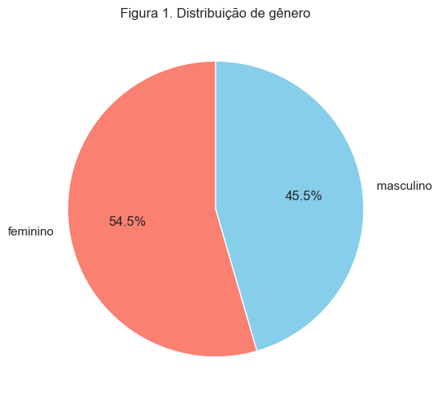

```python
plt.figure(figsize=(6, 6))
df['genero'].value_counts().plot.pie(autopct='%1.1f%%', startangle=90, colors=['salmon', 'skyblue'])
plt.title('Figura 1. Distribuição de gênero')
plt.ylabel('')
plt.show()
```

A porcentagem de indivíduos do gênero feminino é de 54,5%, enquanto a porcentagem de indivíduos do gênero masculino é de 45,5%. Isso indica que há uma leve predominância de mulheres em relação aos homens no grupo analisado, com uma diferença de 9% entre os dois gêneros.

#### 4.1.2. Análise descritiva sobre raça

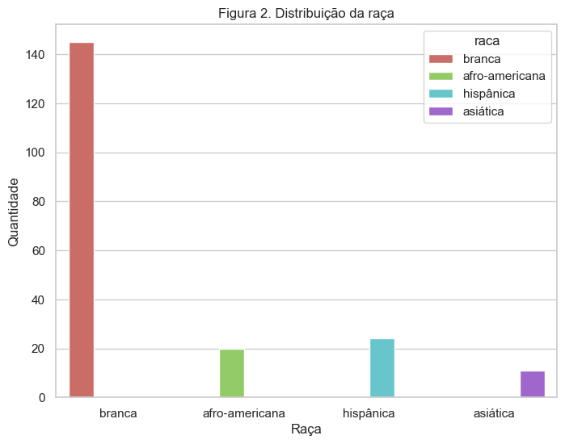

```python
plt.figure(figsize=(8, 6))
sns.countplot(data=data, x='raca', palette='hls', hue='raca')
plt.title('Figura 2. Distribuição da raça')
plt.xlabel('Raça')
plt.ylabel('Quantidade')
plt.show()
```

As categorias apresentadas são "branca", "afro-americana", "hispânica" e "asiática".  
Observações com relação ao gráfico representado pela **Figura 2**:  
1.**Categoria Dominante** : A categoria "branca" tem a maior quantidade, com um valor acima de 140. Isso sugere que os indivíduos nesta categoria constituem a maioria absoluta do conjunto de dados.  
2.**Categorias Minoritárias**: As outras categorias raciais ("afro-americana", "hispânica" e "asiática") possuem contagens significativamente mais baixas. Os grupos "afro-americana" e "hispânica" possuem quantidades quase semelhantes, enquanto a categoria "asiática" tem a contagem mais baixa.  
3.**Disparidade**: Há uma clara disparidade na representação entre a categoria "branca" e as outras categorias, indicando um desequilíbrio na composição racial deste conjunto de dados.  
Essa distribuição pode ser relevante para análises demográficas, e a representação significativa de um grupo pode impactar interpretações em estudos onde a diversidade racial é um fator.

#### 4.1.3. Análise descritiva sobre classe social**

O gráfico apresentado na **Figura 3** representa a distribuição da classe social em um determinado grupo de pessoas. Cada barra representa uma classe social (baixa, média e alta), e a altura da barra indica a quantidade de pessoas que se encaixam nessa classificação.

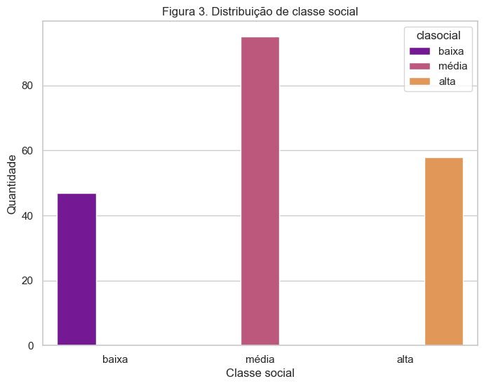

```python
plt.figure(figsize=(8, 6))
sns.countplot(data=data, x='clasocial', palette='plasma', hue='clasocial')
plt.title('Figura 3. Distribuição de classe social')
plt.xlabel('Classe social')
plt.ylabel('Quantidade')
plt.show()
```

Pode-se observar na **Figura 3** que:

- **Maioria classe média:** A barra correspondente à classe média é a mais alta, indicando que a maior parte das pessoas no grupo analisado se classifica como classe média.
- **Classe alta em segundo lugar:** A classe alta possui uma quantidade intermediária de pessoas, ficando em segundo lugar em relação à classe média.
- **Menor quantidade classe baixa:** A extensão da barra representando a classe baixa é a menor, sugerindo que há uma menor quantidade de pessoas nessa categoria.  
  Este gráfico nos permite visualizar a distribuição da classe social de forma clara e concisa. Ele indica que, no grupo analisado, a classe média é predominante, seguida pela classe alta e, por fim, pela classe baixa.

#### 4.1.4. Análise descritiva sobre tipo de currículo**

A **Figura 4** demonstra a quantidade de cada tipo de programa ou currículo (básico, técnico e acadêmico) das escolas da amostra. Cada barra representa um tipo de programa e a altura da barra indica a quantidade total desse tipo.

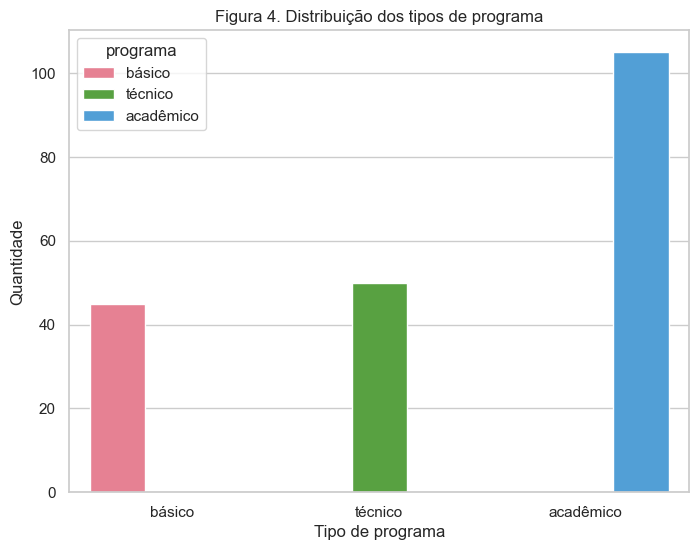

```python
plt.figure(figsize=(8, 6))
sns.countplot(data=data, x='programa', palette='husl', hue='programa')
plt.title('Figura 4. Distribuição dos tipos de programa')
plt.xlabel('Tipo de programa')
plt.ylabel('Quantidade')
plt.show()
```

No gráfico da **Figura 4** pode-se constatar que:

- **Maioria dos programas:** Nota-se que a maior parte dos programas é do tipo acadêmico.  
  A barra correspondente a esse tipo é significativamente mais alta que as demais, indicando um número consideravelmente maior de programas nessa categoria.
- **Menor quantidade:** Os programas básicos apresentam a menor quantidade entre os três tipos.  
  A barra correspondente é a mais baixa do gráfico.
- **Quantidade intermediária:** Os programas técnicos ocupam uma posição intermediária, com uma quantidade maior que os básicos, mas menor que os acadêmicos.

*Sendo assim, com os dados desta amostra, pode-se inferir que:*

- Foco em programas acadêmicos: As instituições ou áreas analisadas possuem um forte foco em programas acadêmicos, com uma oferta muito maior desse tipo de programa em comparação aos demais.
- Diversidade de opções: A instituição oferece uma variedade de programas, abrangendo desde os básicos até os acadêmicos.
- Desigualdade na distribuição: A distribuição dos programas não é uniforme, com uma concentração significativa nos programas acadêmicos.

#### 4.1.5. Análise descritiva multivariada sobre classe social e disciplinas cursadas**

A análise multivariada é uma técnica estatística que analisa a relação entre diferentes variáveis de um conjunto de dados. É uma ferramenta que permite a análise simultânea de três ou mais variáveis, e pode ser usada para identificar padrões e tendências que não seriam percebidos em uma análise isolada e/ou bivariada. Com o intuito de verificar o desempenho de alunos em diferentes disciplinas (leitura, escrita, matemática, ciências e estudos sociais), divididos por classe social (baixa, média e alta) o gráfico da **Figura 5** foi elaborado.

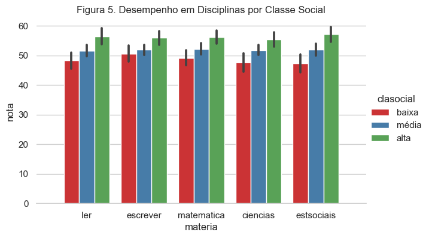

```python
data_long = data.melt(id_vars=["clasocial"],
                      value_vars=["ler", "escrever", "matematica", "ciencias", "estsociais"],
                      var_name="materia", value_name="nota")

sns.set_style('whitegrid')
g = sns.catplot(x="materia", y="nota", hue="clasocial", data=data_long, kind="bar", height=4, aspect=1.5, palette="Set1")
for ax in g.axes.flat:
    sns.despine(ax=ax, left=True)
    ax.margins(x=0.1)
plt.title('Figura 5. Desempenho em Disciplinas por Classe Social')
plt.subplots_adjust(wspace=0, bottom=0.18, left=0.06)
plt.show()
```

#### 4.1.6. Análise descritiva multivariada sobre tipo de escola e disciplinas cursadas**

O gráfico na **Figura 6** nos dá uma visão geral do desempenho dos alunos em escolas públicas e privadas.  
O gráfico mostra que, em geral, as notas são bastante semelhantes nas duas redes de ensino, com pequenas variações em algumas disciplinas.

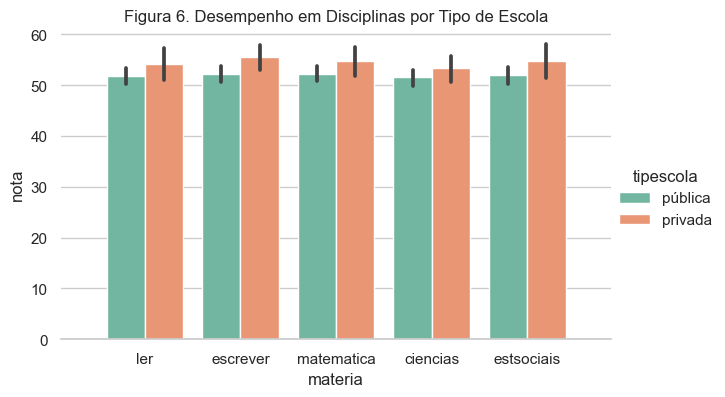

```python
data_long = data.melt(id_vars=["tipescola"],
                      value_vars=["ler", "escrever", "matematica", "ciencias", "estsociais"],
                      var_name="materia", value_name="nota")

sns.set_style('whitegrid')
g = sns.catplot(x="materia", y="nota", hue="tipescola", data=data_long, kind="bar", height=4, aspect=1.5, palette="Set2")
for ax in g.axes.flat:
    sns.despine(ax=ax, left=True)
    ax.margins(x=0.1)
plt.title('Figura 6. Desempenho em Disciplinas por Tipo de Escola')
plt.subplots_adjust(wspace=0, bottom=0.18, left=0.06)
plt.show()
```

Para entender completamente o que os dados da **Figura 6** significam, é preciso considerar o contexto em que os dados foram coletados e outras informações relevantes. Deve-se observar no entanto que se os dados comparam duas turmas de uma mesma série, as notas podem ser muito parecidas, mas cada aluno tem sua própria história e suas próprias dificuldades.  
Com base nas informações fornecidas, pode-se inferir que a pesquisa realizada na High School and Beyond (2024) revela algumas tendências importantes:

1. Distribuição de Gênero: Há uma leve predominância de mulheres (54,5%) em relação aos homens (45,5%) na amostra analisada.
2. Diversidade Étnica: A categoria "branca" é a mais representada, com uma quantidade significativamente maior do que as categorias "afro-americana", "hispânica" e "asiática". Isso indica uma disparidade na composição racial do grupo.
3. Classe Social: A maioria das pessoas pertence à classe média, seguida pela classe alta e, por fim, pela classe baixa.  
   Isso mostra uma predominância da classe média no grupo analisado.
4. Tipos de Programas: A maioria dos programas oferecidos é do tipo acadêmico, com uma quantidade menor de programas técnicos e básicos.  
   Isso sugere um foco maior em programas acadêmicos nas instituições analisadas.
5. Desempenho Escolar por Classe Social: O desempenho dos alunos varia de acordo com a matéria e a classe social, com alunos de classe alta geralmente apresentando melhores resultados.  
   No entanto, essa diferença é mais acentuada em algumas matérias do que em outras.
6. Desempenho em Escolas Públicas e Privadas: As notas dos alunos são bastante semelhantes nas duas redes de ensino, com pequenas variações em algumas disciplinas.  
   Isso indica que, apesar das diferenças contextuais, o desempenho acadêmico é comparável entre escolas públicas e privadas.  
   Essas conclusões destacam a importância de considerar fatores como gênero, diversidade étnica, classe social e tipo de programa ao analisar dados educacionais, pois eles podem influenciar significativamente os resultados e interpretações dos estudos.

## Referências

ALVES, Ana. Estatística Aplicada: Análise de Dados. Editora Aprender Estatística Fácil, 2022. MÉTRICAS BOSS. Os 4 tipos de análise de dados e como fazê-los. Blog de Web Analytics. 2023. Disponível em: https://metricasboss.com.br/artigos/os-4-tipos-de-analise-de-dados-e-como-faze-los. Acesso em: 26 nov. 2024. OPENINTRO. High School and Beyond survey. s/d. Disponível em: https://www.openintro.org/data/index.php?data=hsb2. Acesso em: 26 nov. 2024. NCES. High School & Beyond, National Center for Educational Studies,US Department of Education. Disponivel em: https://nces.ed.gov/surveys/hsb/surveydesign.asp. Acesso em: 26 nov. 2024. QUESTIONPRO, O que é uma investigação longitudinal? Blog do Software de pesquisa QuestionPro. 2024. Disponível em: https://www.questionpro.com/blog/pt-br/investigacao-longitudinal/#:~:text=O%20que%20%C3%A9%20uma%20investiga%C3%A7%C3%A3o,tempo%2C%20geralmente%20anos%20ou%20d%C3%A9cadas. Acesso em: 24 nov. 2024. SIRIUS. Entenda o que é análise descritiva, quais são os tipos e o passo a passo para fazer uma! Blog Sirius Educação. 07 set. 2022. Disponível em: https://blog.sirius.education/analise-descritiva/#:~:text=A%20an%C3%A1lise%20descritiva%20%C3%A9%20usada,algum%20per%C3%ADodo%20ou%20evento%20espec%C3%ADfico. Acesso em: 26 nov. 2024. TATSUOKA, Maurice M. Análise multivariada: técnicas para pesquisa educacional e psicológica (2ª ed.) Nova York: Macmillan, Apêndice F, pp: 430-442, 1988. UNITED STATES DEPARTMENT OF EDUCATION. Institute of Education Sciences. National Center for Education Statistics. High School and Beyond, 1980: A Longitudinal Survey of Students in the United States. Inter-university Consortium for Political and Social Research, 2006-01-12. Disponível em: https://doi.org/10.3886/ICPSR07896.v2. Acesso em 26 nov. 2024.